# HW2: Sathish Angappan

```r
options(warn=-1)
#Load Datasets

d1.train <- read.csv("~/Documents/personal/Data Science/B-CSCI E-109 - Introduction to Data Science/HW2/data/dataset_1_train.txt")

d1.test <- read.csv("~/Documents/personal/Data Science/B-CSCI E-109 - Introduction to Data Science/HW2/data/dataset_1_test.txt")

#Load libraries
library(ggplot2)
library(gam)
```

# Problem 1: Heart Disease Diagnosis

In this problem, the task is to build a model that can diagnose heart disease for a patient presented with chest pain. The data set is provided in the files `dataset_1_train.txt` and `dataset_1_test.txt`, and contains 6 predictors for each patient, along with the diagnosis from a medical professional.

## By visual inspection, do you find that the predictors are good indicators of heart disease in a patient?

### Solution

To determine this, we can convert the data set to a table of frequencies to see whether the predictors are good indicators of heart disease.

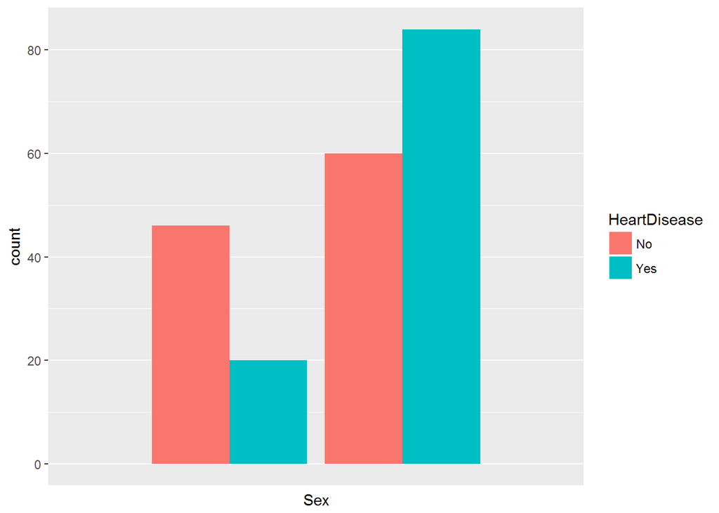

```r
df.sex = data.frame(Sex = d1.train$Sex, HeartDisease = d1.train$HeartDisease)
ggplot(df.sex, aes(Sex, ..count..)) + geom_bar(aes(fill = HeartDisease), position = "dodge") +
scale_x_discrete(breaks=c(0.0,1.0),
        labels=c("Women","Men"))
```

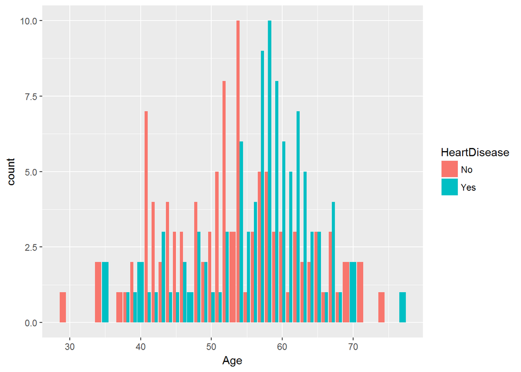

```r
df.Age = data.frame(Age = d1.train$Age, HeartDisease = d1.train$HeartDisease)
ggplot(df.Age, aes(Age, ..count..)) + geom_bar(aes(fill = HeartDisease), position = "dodge")
```

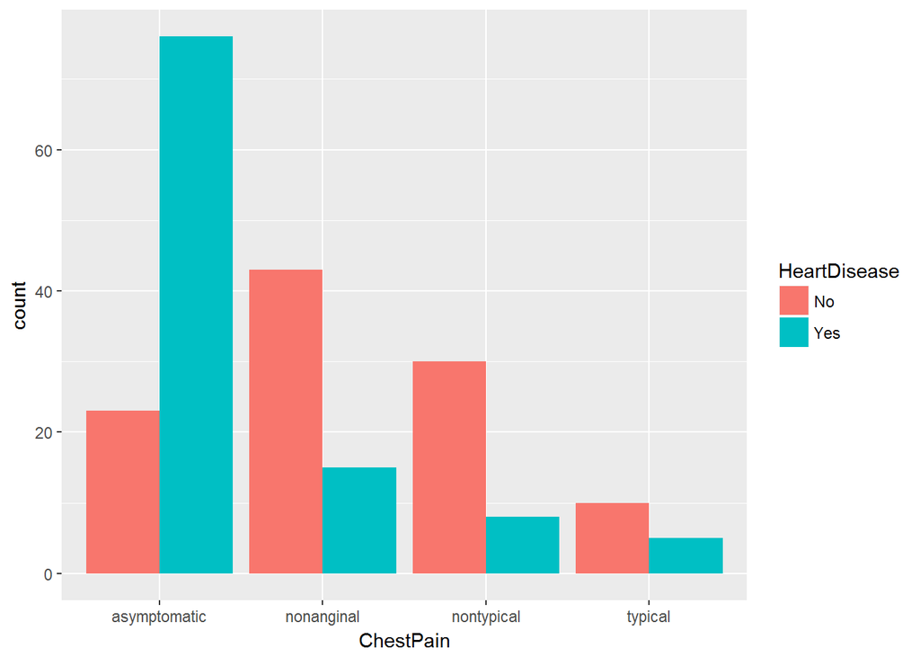

```r
df.ChestPain = data.frame(ChestPain = d1.train$ChestPain, HeartDisease = d1.train$HeartDisease)
ggplot(df.ChestPain, aes(ChestPain, ..count..)) + geom_bar(aes(fill = HeartDisease), position = "dodge")
```

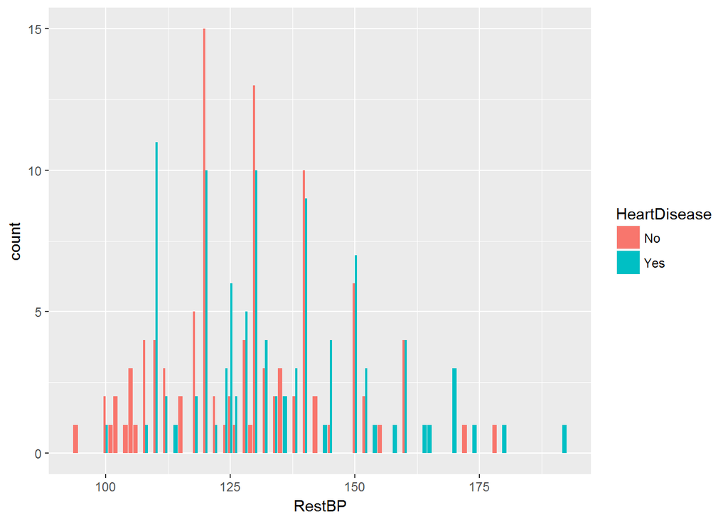

```r
df.RestBP = data.frame(RestBP = d1.train$RestBP, HeartDisease = d1.train$HeartDisease)
ggplot(df.RestBP, aes(RestBP, ..count..)) + geom_bar(aes(fill = HeartDisease), position = "dodge")
```

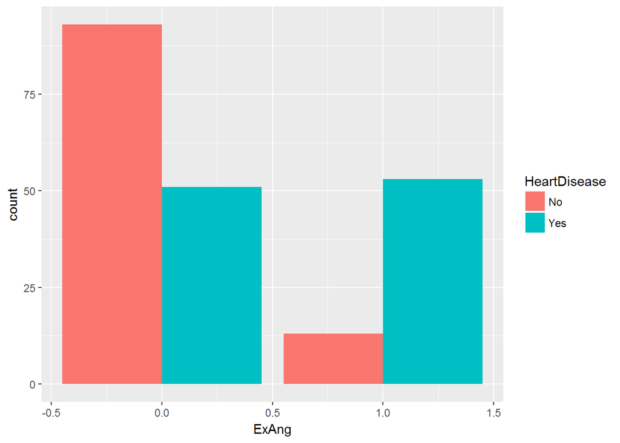

```r
df.ExAng = data.frame(ExAng = d1.train$ExAng, HeartDisease = d1.train$HeartDisease)
ggplot(df.ExAng, aes(ExAng, ..count..)) + geom_bar(aes(fill = HeartDisease), position = "dodge")
```

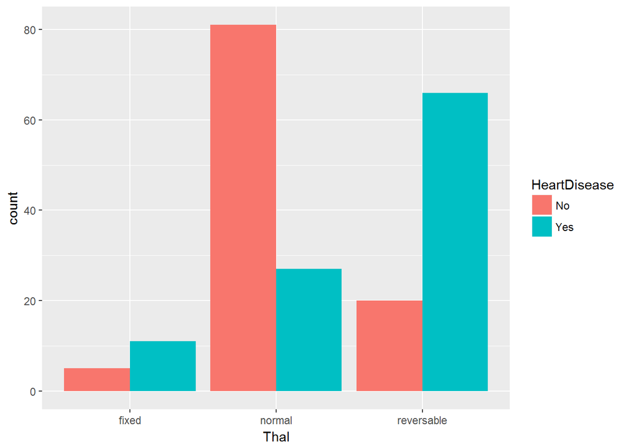

```r
df.Thal = data.frame(Thal = d1.train$Thal, HeartDisease = d1.train$HeartDisease)
ggplot(df.Thal, aes(Thal, ..count..)) + geom_bar(aes(fill = HeartDisease), position = "dodge")
```

From the visual inspection using the graphs above, it is clear that there is variation in heart disease based on different predictor values.

## Apply the generalized additive model (GAM) method to fit a binary classification model

Apply the generalized additive model (GAM) method to fit a binary classification model to the training set and report its classification accuracy on the test set. You may use a smoothing spline basis function wherever relevant, with the smoothing parameter tuned using cross-validation on the training set. Would you be able to apply the smoothing spline basis to categorical predictors? Is there a difference in the way you would handle categorical attributes in `R` compared to `sklearn` in `Python`?

### Solution

#### Categorical Predictors

In Python, we have to convert categorical predictors using hot encoding (or pandas dummies) as 0s and 1s.And then we were required to fit the predictors in the model. In R, though the above is also possible, it was found that, dummies are done automatically by R. So the categorical predictors can be directly used without any conversion.

#### Smoothing spline basis for Categorical predictors

Smoothing spline basis function cannot be applied on Categorical predictors as smoothing lines can be drawn only for quantitative variables.

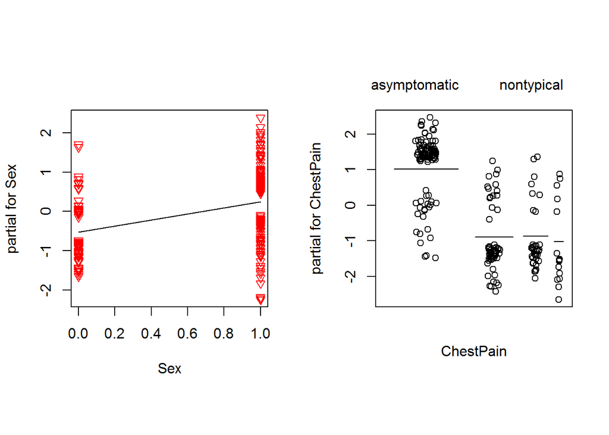

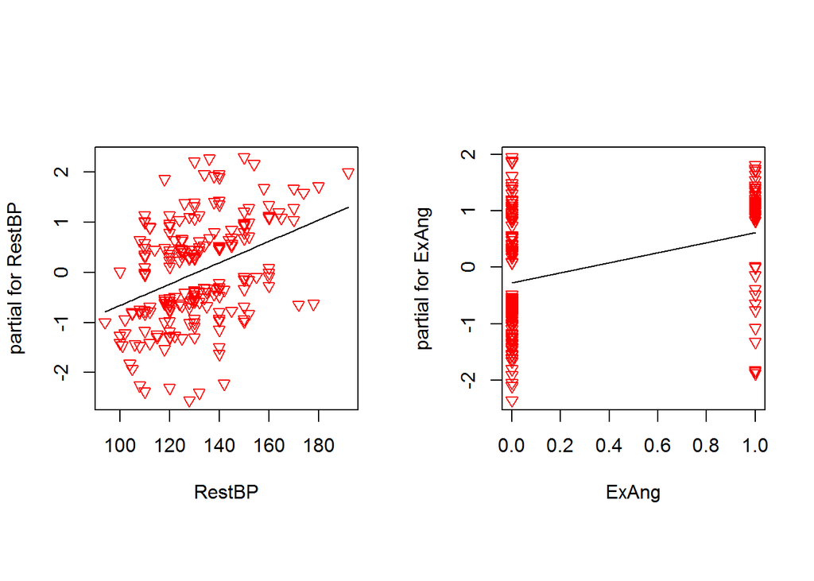

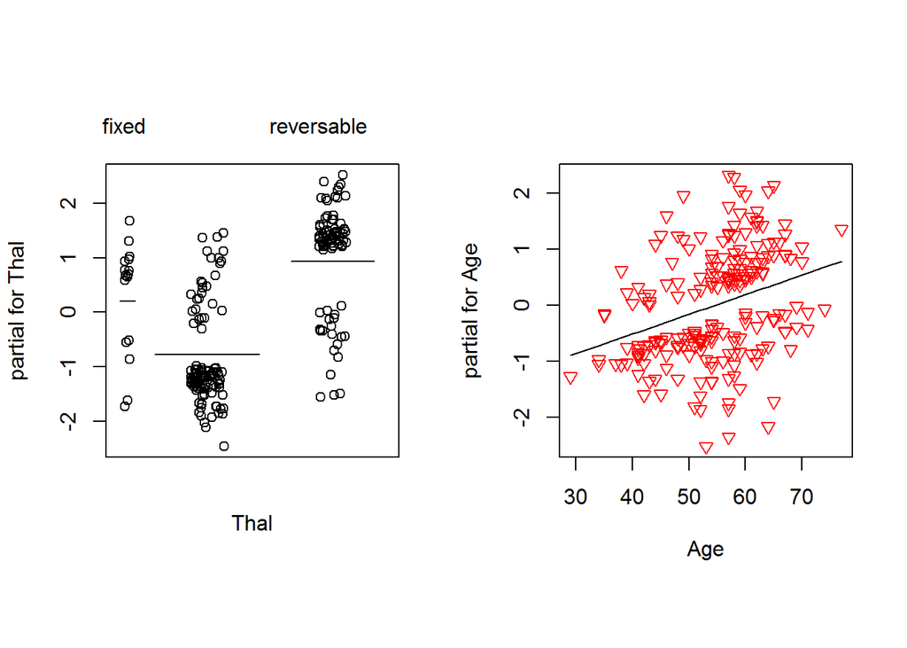

```r
# A simple GAM model fitted for the training data set involving all the predictors.

mod.gam.train.cv = gam(HeartDisease ~ Sex + ChestPain + RestBP + ExAng + Thal + Age, data = d1.train, family = binomial(link = "logit"))
par(pty='s',mfrow=c(1,2))
plot(mod.gam.train.cv, resid=T, rug=F, pch=25, col="red")
```

## Plot the smooth of each predictor for the fitted GAM. By visual inspection, do you find any benefit in modeling the numerical predictors using smoothing splines?

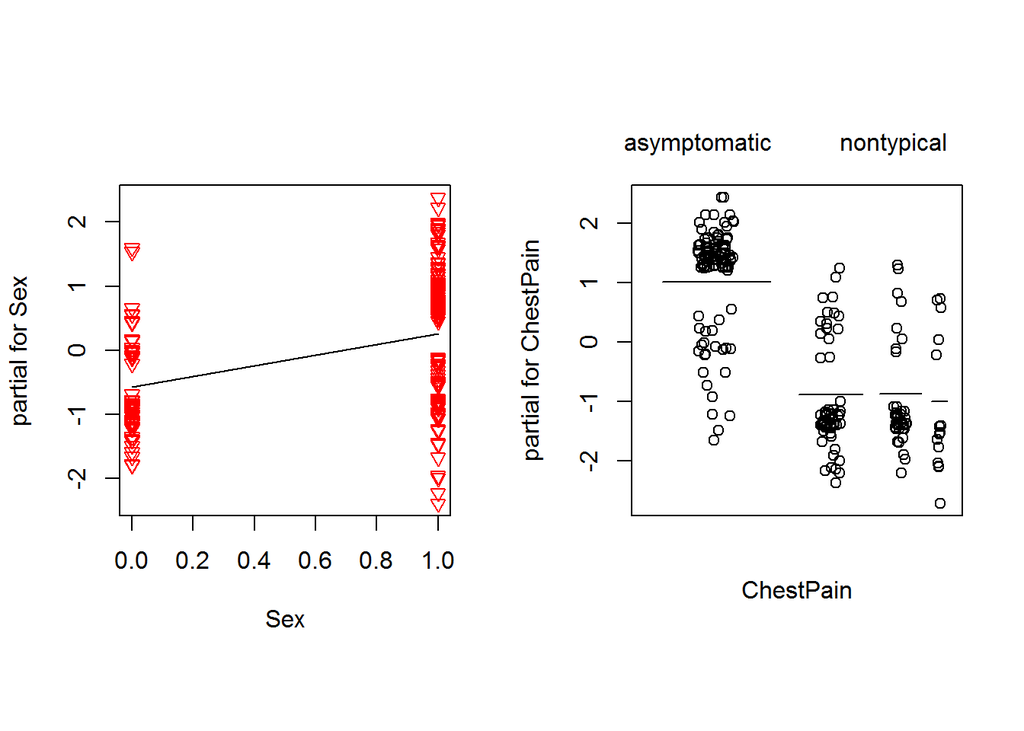

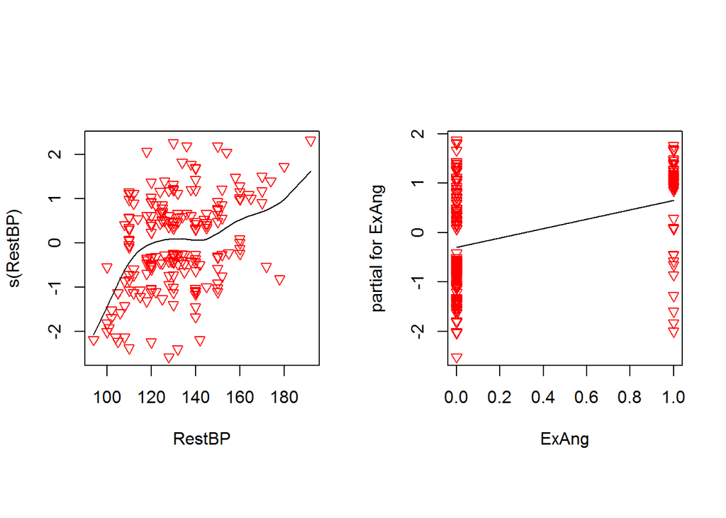

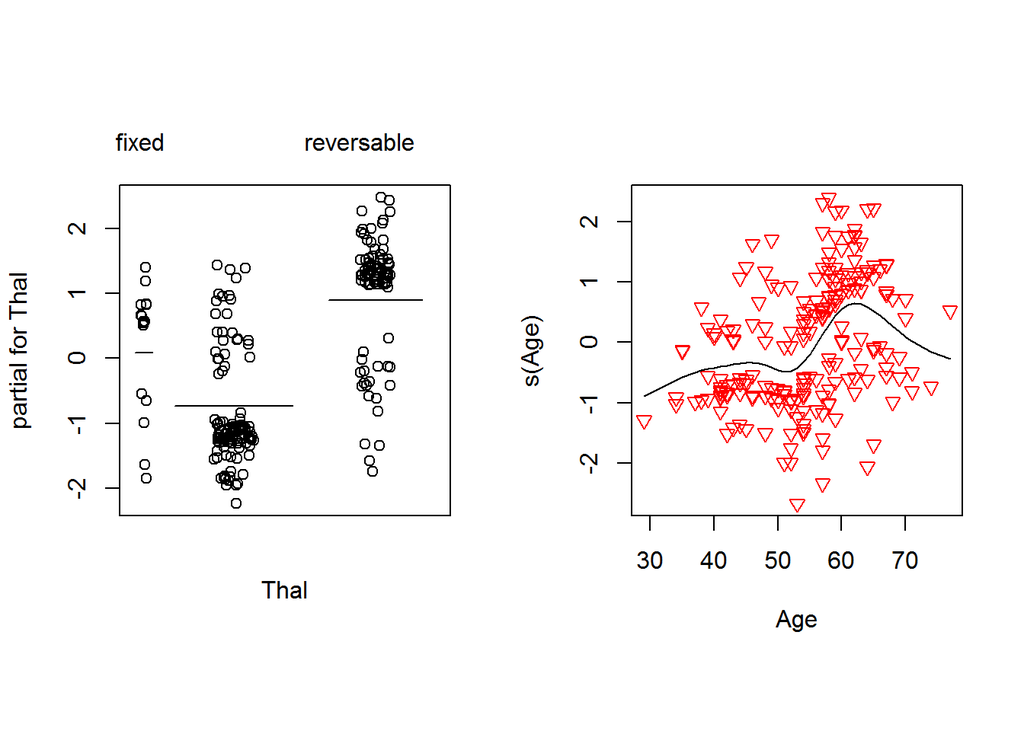

```r
mod.gam.train = gam(HeartDisease ~ Sex + ChestPain + s(RestBP) + ExAng + Thal + s(Age), data = d1.train, family = binomial(link = "logit"))
par(pty='s',mfrow=c(1,2))
plot(mod.gam.train, resid=T, rug=F, pch=25, col="red")
```

when we model the numerical predictors using smoothing splines, we definitely see a difference in the prediction. The curve tends to follow the path relative to the points. We can improve the smoothing splines with more parameters using cross validation and arrive at the best $R^2$.

Based on the graphs above, we can have the following analysis

#### Significance of Sex(Male/Female) towards inclusion in the model

The graph plots the Sex of the person vs inclusion of Sex in the model and we could see a relation here. When we do a probability table, we could also see that, based on the sex, count of patients having heart disease also changes

#### Significance of Chestpain towards inclusion in the model

As we can see from the plot, asymptomatic chest pain has a higher influence over heart disease compared to typical chest pain.

#### Signifcance of ExAng towards inclusion in the model

As we can see from the plot, ExAng has a moderate influence over heart disease.

#### Significance of Resting Blood Pressure(RestBP) towards inclusion in the model

As we can see from the plot, having a higher blood pressure tends to have a higher influence in the heart disease of a patient

#### Significance of Age towards inclusion in the model

As we can see from the plot, once the age crosses 50, there is an abrupt increase in the influence of Heart disesas in the patient. It starts reducing after the age of 60 and stabilizes to the same level as of 70.

You may use the following sample code for cross-validation:

```r
library(boot)

# Function to compute k-fold cross-validation accuracy for a given classification model
cv_accuracy = function(model, data, k) {
  # Input:
  #   'model' - a fitted classification model
  #   'data' - data frame with training data set used to fit the model
  #   'k' - number of folds for CV
  # Output:
  #   'cv_accuracy' - cross-validation accuracy for the model

  acc <- 1 - cv.glm(data, model, K = k)$delta[1]
  return(acc)
}
```

#### Apply Cross Validation to find the best smoothing parameter and apply to test set

```r
df = c(1,2,3,4,5)

accuracy = c()

for(i in 1:length(df)) {
  model.best.spar.ns = gam(HeartDisease ~ Sex + ChestPain + ns(RestBP, df = df[i]) + ExAng + Thal + ns(Age, df = df[i]), data = d1.train, family = binomial(link = "logit"))
  accuracy[i] = cv_accuracy(model.best.spar.ns, d1.train, 5)
}

perf.df = data.frame(df, accuracy)
perf.df
```

```
##   df  accuracy
## 1  1 0.8496511
## 2  2 0.8395212
## 3  3 0.8408552
## 4  4 0.8485218
## 5  5 0.8271692
```

```r
#From the above cross validation, we could see that the accuracy is highest at degrees of freedom = 1. We can use this model on the test data set.

model.best.spar.ns = gam(HeartDisease ~ Sex + ChestPain + ns(RestBP, df = 1) + ExAng + Thal + ns(Age, df = 1), data = d1.train, family = binomial(link = "logit"))

d1.test.predictors = d1.test
#Take only the predictors for the prediction.
d1.test.predictors$HeartDisease = NULL

model.predict = predict(model.best.spar.ns, d1.test.predictors)

summary(model.best.spar.ns)
```

```
##
## Call: gam(formula = HeartDisease ~ Sex + ChestPain + ns(RestBP, df = 1) +
##     ExAng + Thal + ns(Age, df = 1), family = binomial(link = "logit"),
##     data = d1.train)
## Deviance Residuals:
##     Min      1Q  Median      3Q     Max
## -2.4922 -0.6008 -0.2264  0.5802  2.2289
##
## (Dispersion Parameter for binomial family taken to be 1)
##
##     Null Deviance: 291.1028 on 209 degrees of freedom
## Residual Deviance: 181.6187 on 200 degrees of freedom
## AIC: 201.6187
##
## Number of Local Scoring Iterations: 5
##
## Anova for Parametric Effects
##                     Df  Sum Sq Mean Sq F value    Pr(>F)
## Sex                  1   4.364  4.3639  4.0567 0.0453363 *
## ChestPain            3  26.971  8.9904  8.3575 2.914e-05 ***
## ns(RestBP, df = 1)   1   5.953  5.9532  5.5341 0.0196213 *
## ExAng                1   4.256  4.2560  3.9563 0.0480585 *
## Thal                 2  16.935  8.4675  7.8714 0.0005121 ***
## ns(Age, df = 1)      1   2.155  2.1547  2.0030 0.1585398
## Residuals          200 215.147  1.0757
## ---
## Signif. codes:  0 '***' 0.001 '**' 0.01 '*' 0.05 '.' 0.1 ' ' 1
```

## Using a likelihood ratio test, compare the fitted GAM with the following models:

### (i) a GAM with only the intercept term

```r
mod.gam.train.int = gam(HeartDisease ~ 1, data = d1.train, family = binomial(link = "logit"))

anova(mod.gam.train.int, model.best.spar.ns, test = "Chi")
```

```
## Analysis of Deviance Table
##
## Model 1: HeartDisease ~ 1
## Model 2: HeartDisease ~ Sex + ChestPain + ns(RestBP, df = 1) + ExAng +
##     Thal + ns(Age, df = 1)
##   Resid. Df Resid. Dev Df Deviance  Pr(>Chi)
## 1       209     291.10
## 2       200     181.62  9   109.48 < 2.2e-16 ***
## ---
## Signif. codes:  0 '***' 0.001 '**' 0.01 '*' 0.05 '.' 0.1 ' ' 1
```

Here the p value < 0.05. This means that the model containing smoothing splines with all the predictors is a much better fit than the model with just the intercept.

### (ii) a GAM with only categorical predictors

```r
mod.gam.train.catg = gam(HeartDisease ~ Sex + ChestPain + ExAng + Thal, data = d1.train, family = binomial(link = "logit"))

anova(mod.gam.train.catg, model.best.spar.ns, test = "Chi")
```

```
## Analysis of Deviance Table
##
## Model 1: HeartDisease ~ Sex + ChestPain + ExAng + Thal
## Model 2: HeartDisease ~ Sex + ChestPain + ns(RestBP, df = 1) + ExAng +
##     Thal + ns(Age, df = 1)
##   Resid. Df Resid. Dev Df Deviance Pr(>Chi)
## 1       202     189.75
## 2       200     181.62  2   8.1349  0.01712 *
## ---
## Signif. codes:  0 '***' 0.001 '**' 0.01 '*' 0.05 '.' 0.1 ' ' 1
```

Here the p value < 0.05. The probability of this model is higher than the intercept model. But still less than 0.05. This means that the model containing smoothing splines with all the predictors is a much better fit than the model with just the model containing the categorical variables.

### (iii) a GAM with all predictors entered linearly

```r
mod.gam.train.lin = gam(HeartDisease ~ Sex + ChestPain + RestBP + ExAng + Thal + Age, data = d1.train, family = binomial(link = "logit"))

anova(mod.gam.train.lin, model.best.spar.ns, test = "Chi")
```

```
## Analysis of Deviance Table
##
## Model 1: HeartDisease ~ Sex + ChestPain + RestBP + ExAng + Thal + Age
## Model 2: HeartDisease ~ Sex + ChestPain + ns(RestBP, df = 1) + ExAng +
##     Thal + ns(Age, df = 1)
##   Resid. Df Resid. Dev Df    Deviance Pr(>Chi)
## 1       200     181.62
## 2       200     181.62  0 -5.6843e-14
```

In this case, both models are same. The model with a smoothing spline uses degree of freedom = 1 which is nothing but a linear GAM model. Hence there is no difference in the models.